# Forecasting the Popularity of AI Tools in 2025: Analysis on Global Search Trends

Sulistia_Fahri

```r
# Load library
library(readr)
library(dplyr)
library(lmtest)
library(tidyr)
library(tidyverse)
```

```r
library(ggplot2)
library(forecast)
library(lubridate)
library(tseries)
library(zoo)      # untuk konversi data menjadi tipe Date (to confirmatory the data be date type)
library(reshape2)  # Untuk melt data # for melt data
library(purrr)  # Untuk fungsi map_dfr() # for function map_dfr()
```

```r
# Load data
data <- read_csv("C:/Users/ASUS/Downloads/multiTimeline.csv", skip = 1)
# Cek struktur data
#structure data check
str(data)
```

```
## spc_tbl_ [126 × 6] (S3: spec_tbl_df/tbl_df/tbl/data.frame)
##  $ Week                    : Date[1:126], format: "2023-01-01" "2023-01-08" ...
##  $ ChatGPT: (Worldwide)    : num [1:126] 5 8 9 12 15 17 18 17 16 16 ...
##  $ "Gemini AI": (Worldwide): chr [1:126] "0" "0" "0" "0" ...
##  $ "Claude AI": (Worldwide): chr [1:126] "0" "<1" "<1" "<1" ...
##  $ midjourney: (Worldwide) : chr [1:126] "1" "1" "1" "1" ...
##  $ DeepSeek: (Worldwide)   : chr [1:126] "0" "0" "0" "0" ...
##  - attr(*, "spec")=
##   .. cols(
##   ..   Week = col_date(format = ""),
##   ..   `ChatGPT: (Worldwide)` = col_double(),
##   ..   `"Gemini AI": (Worldwide)` = col_character(),
##   ..   `"Claude AI": (Worldwide)` = col_character(),
##   ..   `midjourney: (Worldwide)` = col_character(),
##   ..   `DeepSeek: (Worldwide)` = col_character()
##   .. )
##  - attr(*, "problems")=<externalptr>
```

```r
# Cara Mengubah nilai dalam data
# The way to Change data's value
data$`"Gemini AI": (Worldwide)`[data$`"Gemini AI": (Worldwide)` == "<1"] <- 0
data$`"Claude AI": (Worldwide)`[data$`"Claude AI": (Worldwide)` == "<1"] <- 0
data$`midjourney: (Worldwide)`[data$`midjourney: (Worldwide)` == "<1"] <- 0
data$`DeepSeek: (Worldwide)`[data$`DeepSeek: (Worldwide)` == "<1"] <- 0

# Cara Mengubah tipe data karakter ke nomor/bilangan
# The way to Change character data type to the number type
data$`midjourney: (Worldwide)` <- as.numeric(data$`midjourney: (Worldwide)`)
data$`DeepSeek: (Worldwide)` <- as.numeric(data$`DeepSeek: (Worldwide)`)
data$`"Gemini AI": (Worldwide)`<- as.numeric(data$`"Gemini AI": (Worldwide)`)
data$`"Claude AI": (Worldwide)`<- as.numeric(data$`"Claude AI": (Worldwide)`)
str(data)
```

```
## spc_tbl_ [126 × 6] (S3: spec_tbl_df/tbl_df/tbl/data.frame)
##  $ Week                    : Date[1:126], format: "2023-01-01" "2023-01-08" ...
##  $ ChatGPT: (Worldwide)    : num [1:126] 5 8 9 12 15 17 18 17 16 16 ...
##  $ "Gemini AI": (Worldwide): num [1:126] 0 0 0 0 0 0 0 0 0 0 ...
##  $ "Claude AI": (Worldwide): num [1:126] 0 0 0 0 0 0 0 0 0 0 ...
##  $ midjourney: (Worldwide) : num [1:126] 1 1 1 1 1 1 1 1 1 1 ...
##  $ DeepSeek: (Worldwide)   : num [1:126] 0 0 0 0 0 0 0 0 0 0 ...
##  - attr(*, "spec")=
##   .. cols(
##   ..   Week = col_date(format = ""),
##   ..   `ChatGPT: (Worldwide)` = col_double(),
##   ..   `"Gemini AI": (Worldwide)` = col_character(),
##   ..   `"Claude AI": (Worldwide)` = col_character(),
##   ..   `midjourney: (Worldwide)` = col_character(),
##   ..   `DeepSeek: (Worldwide)` = col_character()
##   .. )
##  - attr(*, "problems")=<externalptr>
```

```r
# Cara mengubah format ke time series (format data mingguan (52 observasi per tahun))
# The way to Change format of data to time series (Weekly data (52 observations yearly))
ts_chatgpt <- ts(data$`ChatGPT: (Worldwide)`, start = c(2023, 1), frequency = 52)
ts_gemini <- ts(data$`"Gemini AI": (Worldwide)`, start = c(2023, 1), frequency = 52)
ts_claude <- ts(data$`"Claude AI": (Worldwide)`, start = c(2023, 1), frequency = 52)
ts_midjourney <- ts(data$`midjourney: (Worldwide)`, start = c(2023, 1), frequency = 52)
ts_deepseek <- ts(data$`DeepSeek: (Worldwide)`, start = c(2023, 1), frequency = 52)
```

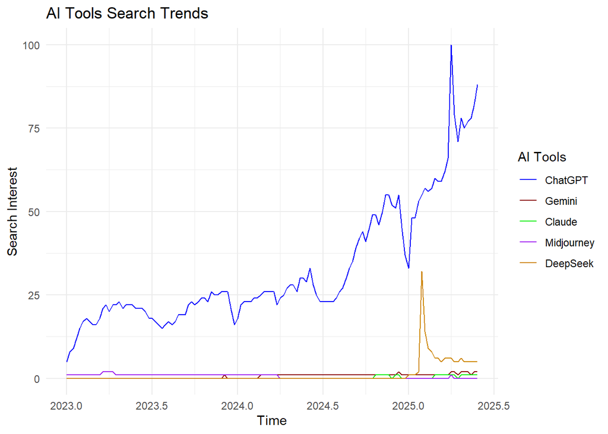

```r
# Gabungkan semua time series
# Group multiple time series
data_plot <- data.frame(
  Time = time(ts_chatgpt),
  ChatGPT = as.numeric(ts_chatgpt),
  Gemini = as.numeric(ts_gemini),
  Claude = as.numeric(ts_claude),
  Midjourney = as.numeric(ts_midjourney),
  DeepSeek = as.numeric(ts_deepseek)
)

# Ubah format ke long
# Change the format to long
data_long <- melt(data_plot, id.vars = "Time")

# Buat plot
# Make the plot
ggplot(data_long, aes(x = Time, y = value, color = variable)) +
  geom_line() +
  scale_color_manual(values = c("blue", "red4", "green2", "purple", "orange3")) +
  labs(title = "AI Tools Search Trends",
       y = "Search Interest",
       x = "Time",
       color = "AI Tools") +
  theme_minimal()
```

grafik di atas menunjukkan bahwa AI paling banyak digunakan adalah Chat GPT. Hal ini dilihat berdasarkan garis dalam grafik yang terus meninggkat. the Graph show that the most used AI tools is Chat GPT, this is seen through the line that continues to increase.

```r
# Uji stasioneritas terhadap mean
# stasionerity test on mean
adf_pvals <- sapply(data[,-1], function(x) adf.test(x)$p.value)

# Buat data frame hasilnya
# make the result in data frame
result <- data.frame(
  `ADF p-value` = round(adf_pvals, 4),
  Stasioner = ifelse(adf_pvals < 0.05, "Stationery", "Not Stationery")
)
print(result)
```

```
##                          ADF.p.value      Stasioner
## ChatGPT: (Worldwide)          0.9742 Not Stationery
## "Gemini AI": (Worldwide)      0.3271 Not Stationery
## "Claude AI": (Worldwide)      0.0905 Not Stationery
## midjourney: (Worldwide)       0.2444 Not Stationery
## DeepSeek: (Worldwide)         0.0775 Not Stationery
```

Hipotesis (Hypothesis):

H0: Data tidak stasioner (Data is not stationery)

H1: Data stasioner (Data is stationary)

Jika p−value< α maka data stastioner (If p-value < α so data is stationery).

Dapat dilihat bahwa p-value > α (0,05). The output show that p-value > α (0.05).

Karena p-value > 0.05, maka tidak bisa menolak H0 dan menyimpulkan bahwa data tidak stasioner. because p-value > 0.05, so can’t to reject H0 and show that the data is not stationery.

```r
# Melakukan differencing karna tidak stasioner terhadap mean
# Make a defentiation cause data not stasionery on mean
ts_diff <- data.frame(
  diff(data$`ChatGPT: (Worldwide)`, differences = 1),
  diff(data$`"Claude AI": (Worldwide)`, differences = 1),
  diff(data$`"Gemini AI": (Worldwide)`, differences = 1),
  diff(data$`midjourney: (Worldwide)`, differences = 1),
  diff(data$`DeepSeek: (Worldwide)`, differences = 1)
)

# ADF test
adf_pvals_diff <- sapply(ts_diff, function(x) adf.test(x)$p.value)
# Buat data frame hasilnya
# make the result in data frame
result_diff <- data.frame(
  `ADF p-value` = round(adf_pvals_diff, 4),
  Stasioner = ifelse(adf_pvals_diff < 0.05, "Stationery", "Not Stationery")
)

# Tampilkan hasil
print(result_diff)
```

```
##                                                        ADF.p.value  Stasioner
## diff.data..ChatGPT...Worldwide....differences...1.            0.01 Stationery
## diff.data...Claude.AI....Worldwide....differences...1.        0.01 Stationery
## diff.data...Gemini.AI....Worldwide....differences...1.        0.01 Stationery
## diff.data..midjourney...Worldwide....differences...1.         0.01 Stationery
## diff.data..DeepSeek...Worldwide....differences...1.           0.01 Stationery
```

Hipotesis (Hypothesis):

H0: Data tidak stasioner (Data is not stationery)

H1: Data stasioner (Data is stationary)

Jika p−value< α maka data stastioner (If p-value < α so data is stationery).

Dapat dilihat bahwa p-value < α (0,05). The output show that p-value < α (0.05).

Karena p-value < 0.05, maka bisa menolak H0 dan menyimpulkan bahwa data stasioner. because p-value < 0.05, so rejects H0 and show that the data is stationery.

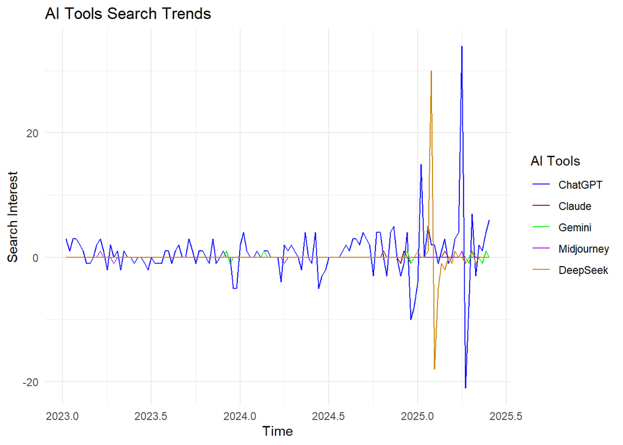

```r
# Plot hasil differencing
# Resul plot Differenced

data_plot_diff <- data.frame(
  Time = time(ts_chatgpt)[-1],  # Hilangkan observasi pertama karena differencing
  ChatGPT = as.numeric(diff(ts_chatgpt)),
  Claude = as.numeric(diff(ts_claude)),
  Gemini = as.numeric(diff(ts_gemini)),
  Midjourney = as.numeric(diff(ts_midjourney)),
  DeepSeek = as.numeric(diff(ts_deepseek))
)

# Ubah format ke long
data_long1 <- melt(data_plot_diff, id.vars = "Time")

# Plot dengan ggplot
ggplot(data_long1, aes(x = Time, y = value, color = variable)) +
  geom_line() +
  scale_color_manual(values = c("blue", "red4", "green2", "purple", "orange3")) +
  labs(title = "AI Tools Search Trends",
       y = "Search Interest",
       x = "Time",
       color = "AI Tools") +
  theme_minimal()
```

```r
#Pembentukan model, Uji White Noise Model, dan Uji normalitas Model
#model formation dan White Noise test, and normality test model
model1 <- auto.arima(ts_chatgpt)
model2 <- auto.arima(ts_claude)
model3 <- auto.arima(ts_gemini)
model4 <- auto.arima(ts_midjourney)
model5 <- auto.arima(ts_deepseek)

# Simpan semua model dalam list
# Save model in the list
models <- list(
  chatgpt = model1,
  claudeai = model2,
  gemini = model3,
  midjourney = model4,
  deepdeek = model5
)

# 1. Pembentukan model (model formation)
diagnostics <- data.frame(
  Model = names(models), # Use the name from list before

# White Noise test/Ljung-Box Test
LB_pvalue = sapply(models,
                    function(m) Box.test(m$residuals, type="Ljung-Box")$p.value),

# normality test using Shapiro-Wilk Test
SW_pvalue = sapply(models,
                    function(m) shapiro.test(m$residuals)$p.value)
) %>%
  mutate(
    LB_Conclusion = ifelse(LB_pvalue > 0.05, "White Noise", "Not White Noise"),
    SW_Conclusion = ifelse(SW_pvalue > 0.05, "Normal", "Non-Normal")
  )
print(diagnostics)
```

```
##                 Model LB_pvalue    SW_pvalue LB_Conclusion SW_Conclusion
## chatgpt       chatgpt 0.9558090 1.168473e-14   White Noise    Non-Normal
## claudeai     claudeai 0.8316617 6.499336e-20   White Noise    Non-Normal
## gemini         gemini 0.9524684 1.221476e-17   White Noise    Non-Normal
## midjourney midjourney 0.9832991 8.531589e-22   White Noise    Non-Normal
## deepdeek     deepdeek 0.8208379 2.906072e-24   White Noise    Non-Normal
```

Berdasarkan output di atas menunjukkan bahwa model memenuhi syarat white noise walaupun tidak berdistribusi normal Base on the output showed that the models qualified for White Noise although not normally distributed

```r
#Significant test

# membuat fungsi untuk membuat tabel signifikansi
# make a function for significance table
create_sig_table <- function(model_list) {
  result <- data.frame()

  for (model_name in names(model_list)) {
    model <- model_list[[model_name]]
    ct <- coeftest(model)

    temp_df <- data.frame(
      Model = model_name,
      Koefisien = rownames(ct),
      Estimate = ct[,1],
      Std.Error = ct[,2],
      z.value = ct[,3],
      p.value = ct[,4],
      Signifikan = ifelse(ct[,4] < 0.05, "Signifikan", "Not Signifikan"),
      stringsAsFactors = FALSE
    )

    result <- rbind(result, temp_df)
  }

  return(result)
}

significance_table <- create_sig_table(models) #Membuat tabel signifikansi (make significance table)
print(significance_table)
```

```
##             Model Koefisien    Estimate   Std.Error    z.value      p.value
## ma1       chatgpt       ma1 -0.18685129 0.089562303  -2.086272 3.695402e-02
## ma2       chatgpt       ma2 -0.19041559 0.091271598  -2.086252 3.695577e-02
## drift     chatgpt     drift  0.62862358 0.249857916   2.515924 1.187207e-02
## 1        claudeai       ma1 -0.38682648 0.086321321  -4.481239 7.421090e-06
## ma11       gemini       ma1 -0.61592076 0.070129091  -8.782671 1.596372e-18
## drift1     gemini     drift  0.01494814 0.008399381   1.779671 7.512976e-02
## 11     midjourney       ma1 -0.21554247 0.092541418  -2.329146 1.985134e-02
## ar1      deepdeek       ar1  0.35732877 0.117978140   3.028771 2.455507e-03
## ma12     deepdeek       ma1 -0.86984924 0.067698685 -12.848835 8.731523e-38
##            Signifikan
## ma1        Signifikan
## ma2        Signifikan
## drift      Signifikan
## 1          Signifikan
## ma11       Signifikan
## drift1 Not Signifikan
## 11         Signifikan
## ar1        Signifikan
## ma12       Signifikan
```

Berdasarkan output di atas menunjukkan bahwa sebagian besar model merupakan model yang signifikan Base on the output showed almost all models are a significant.

```r
# prediksi 12 minggu ke depan
# predict for 12 weeks after
forecast_chatgpt <- forecast(model1, h = 12)
forecast_claudeai <- forecast(model2, h = 12)
forecast_gemini <- forecast(model3, h = 12)
forecast_midjourney <- forecast(model4, h = 12)
forecast_deepseek <- forecast(model5, h = 12)

# 1. Ambil data historis (dari model)
# 1. take the historical data (from model)
real_date <- time(model1$x)
real_data <- data.frame(
  Date = as.Date(as.yearmon(real_date)),
  ChatGPT = as.numeric(model1$x),
  ClaudeAI = as.numeric(model2$x),
  Gemini = as.numeric(model3$x),
  Midjourney = as.numeric(model4$x),
  DeepSeek = as.numeric(model5$x),
  Discription = "Actual"
)

# 2. Ambil data prediksi (forecast$mean)
# 2. take the prediction data (forecast$mean)
predict_date <- time(forecast_chatgpt$mean)
predict_data <- data.frame(
  Date = as.Date(as.yearmon(predict_date)),
  ChatGPT = as.numeric(forecast_chatgpt$mean),
  ClaudeAI = as.numeric(forecast_claudeai$mean),
  Gemini = as.numeric(forecast_gemini$mean),
  Midjourney = as.numeric(forecast_midjourney$mean),
  DeepSeek = as.numeric(forecast_deepseek$mean),
  Discription = "Prediction"
)

# 3. Gabungkan data historis + prediksi
# 3. combine the historical and prediction data
Combined_data <- bind_rows(real_data, predict_data)
head(Combined_data, 5)
```

```
##         Date ChatGPT ClaudeAI Gemini Midjourney DeepSeek Discription
## 1 2023-01-01       5        0      0          1        0      Actual
## 2 2023-01-01       8        0      0          1        0      Actual
## 3 2023-01-01       9        0      0          1        0      Actual
## 4 2023-01-01      12        0      0          1        0      Actual
## 5 2023-01-01      15        0      0          1        0      Actual
```

```r
tail(Combined_data, 5)
```

```
##           Date  ChatGPT  ClaudeAI   Gemini   Midjourney DeepSeek Discription
## 134 2025-07-01 90.08856 0.9979439 1.964131 3.654536e-06 5.399040  Prediction
## 135 2025-07-01 90.71719 0.9979439 1.979079 3.654536e-06 5.399108  Prediction
## 136 2025-08-01 91.34581 0.9979439 1.994028 3.654536e-06 5.399132  Prediction
## 137 2025-08-01 91.97443 0.9979439 2.008976 3.654536e-06 5.399141  Prediction
## 138 2025-08-01 92.60306 0.9979439 2.023924 3.654536e-06 5.399144  Prediction
```

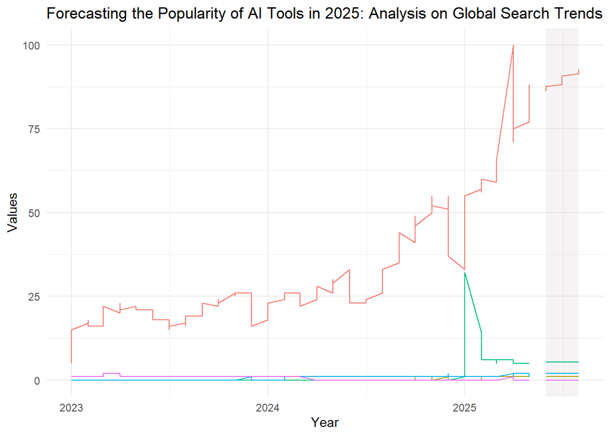

```r
# Ubah ke long format
# change to long format
df_long <- Combined_data %>%
  pivot_longer(cols = c(ChatGPT, ClaudeAI, Gemini, Midjourney, DeepSeek),
               names_to = "AI_type",
               values_to = "Values")

# Pastikan kolom tanggal dalam format Date
# make sure that the Date is in Date format/type
df_long$tanggal <- as.Date(df_long$Date)

# Ambil rentang tanggal untuk data prediksi
# take the rate of date for prediction data
pred_range <- df_long %>%
  filter(Discription == "Prediction") %>%
  summarise(start = min(Date), end = max(Date))

ggplot() +
  # Ubah Latar belakang untuk data prediksi
  # change the background of data prediction
  geom_rect(data = pred_range,
            aes(xmin = start, xmax = end, ymin = -Inf, ymax = Inf),
            fill = "lavenderblush3", alpha = 0.2) +

  # Garis data semua AI
  # make the data line for all AI
  geom_line(data = df_long,
            aes(x = Date, y = Values, color = AI_type, group = interaction(AI_type, Discription)),
            size = 0.5) +

  labs(title = "Forecasting the Popularity of AI Tools in 2025: Analysis on Global Search Trends",
       x = "Year",
       y = "Values",
       color = "AI Type") +
  theme_minimal() +
  theme(legend.position = "side")
```

```r
# Nilai akurasi
# Akuaration Value

# Fungsi untuk ekstrak metrik akurasi
# function for extract accuracy matrix
get_accuracy <- function(model) {
  acc <- accuracy(model)
  data.frame(
    RMSE = acc[,"RMSE"],
    MAE = acc[,"MAE"]
  )
}

# Gabungkan hasil akurasi semua model
# Combine the result of all models
accuracy_table <- map_dfr(models, get_accuracy, .id = "Model") %>%
  mutate_if(is.numeric, round, 4)

print(accuracy_table)
```

```
##        Model   RMSE    MAE
## 1    chatgpt 4.4296 2.4458
## 2   claudeai 0.2215 0.0680
## 3     gemini 0.2403 0.1194
## 4 midjourney 0.1949 0.0462
## 5   deepdeek 2.7676 0.3534
```

Berdasarkan hasil akurasi yang didapatkan menunjukkan bahwa hasil prediksi yang dihasilkan cukup baik dengan tingkat kesalahan yang rendah. Hal ini dapat dilihat melalui nilai RMSE dan MAE yang relatif kecil. Based on the accuracy results, it shows that the prediction results generated are quite good with a small error rate. This is indicated by the relatively small RMSE and MAE values.